# Lab 03: Data Exploration and Deterministic Functions

Ednita Tavarez-Jimenez

# **Basal Area**

Q5 (1 pt.): What is basal area, and how is it measured?

The Basal Area is the average number of an area. It is measured square feet per acre.

Q2 (2 pts.): Include a figure of your terrain/basal area pairplot.

```r
#install.packages("psych")
require(psych)
require(here)
dat_bird = read.csv(
  here("data", "bird.sta.csv"))
head(dat_bird)
```

```
##   basin sub sta AMCR AMDI AMGO AMRO BCCH BEWR BGWA BHCO BHGR BRCR BTPI BUSH
## 1     D  AL   1    0    0    0    1    0    0    0    0    2    0    0    0
## 2     D  AL   2    0    0    0    0    0    0    0    0    2    0    0    0
## 3     D  AL   3    0    0    0    0    0    1    0    0    0    0    0    0
## 4     D  AL   4    0    0    0    0    0    0    0    0    0    0    0    0
## 5     D  AL   5    0    0    0    0    0    0    0    0    0    0    0    0
## 6     D  AL   6    0    0    0    0    0    0    0    0    1    1    0    0
##   CBCH CEWA CORA COYE DEJU DOWO EUST EVGR GCKI GCSP GRJA HAFL HAWO HETH HEWA
## 1    2    0    0    0    0    0    0    0    0    0    0    0    0    0    0
## 2    2    0    0    0    0    0    0    0    0    0    0    0    2    0    0
## 3    0    0    0    0    0    0    0    0    0    0    0    0    1    0    0
## 4    1    0    0    0    0    0    0    0    0    0    0    0    0    0    0
## 5    1    0    0    0    0    0    0    0    1    0    0    0    0    0    0
## 6    0    0    0    0    0    0    0    0    0    0    0    0    0    0    0
##   HOME HOWR HUVI MALL MAMU MGWA MOQU NOFL OCWA OSFL PISI PIWO PSFL PUFI PYOW
```

[output cut: 27 more lines]

```r
dat_hab = read.csv(here("data", "hab.sta.csv"))

head(dat_hab)
```

```
##   basin sub sta     lat     long elev slope aspect s.id s.edge p.edge p.edge.1
## 1     D  AL   1 4924418 437009.8  542    75     15    3      E      E      131
## 2     D  AL   2 4924430 437200.6  519    80    326    2      E      E      192
## 3     D  AL   3 4924416 437430.8  584    70    230    1      I      I        0
## 4     D  AL   4 4923998 437731.0  612    60    208    3      I      E      120
## 5     D  AL   5 4923999 437544.2  580    43    235    3      I      I        0
## 6     D  AL   6 4924008 437327.2  554    65     60    3      I      E      166
##   p.cwedge ba.con ba.hard ba.snag ba.tot ba.ratio snag.sml snag.ml snag.l
## 1       79      0       5       0      5        0        7       4      0
## 2      175     18       0      18     18      100       67      46     32
## 3        0      0       0       5      0       50       14      11      4
## 4        6      9      14       0     23       40        4       4      4
## 5        0     14       0       0     14      100        0       0      0
## 6        8      9       0       5      9      100       21       7      7
##   snag.dc1 snag.dc2 snag.dc4
## 1        4        0        4
## 2       28       21       18
## 3        0        4       11
## 4        0        0        4
## 5        0        0        0
## 6        7        0       14
```

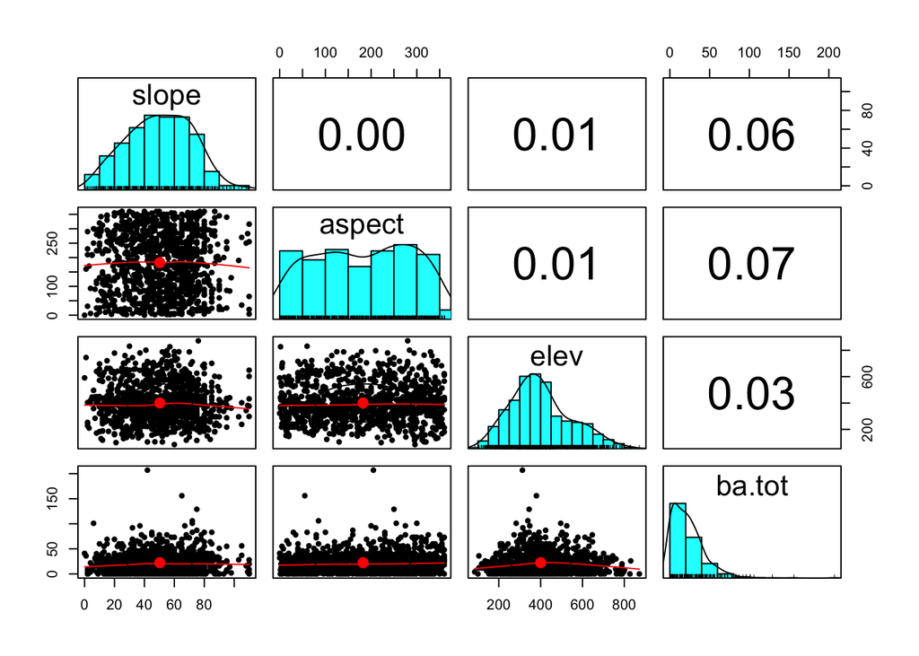

```r
data_all <- merge(dat_bird, dat_hab)
pairs.panels(data_all[, c("slope", "aspect", "elev","ba.tot")])
```

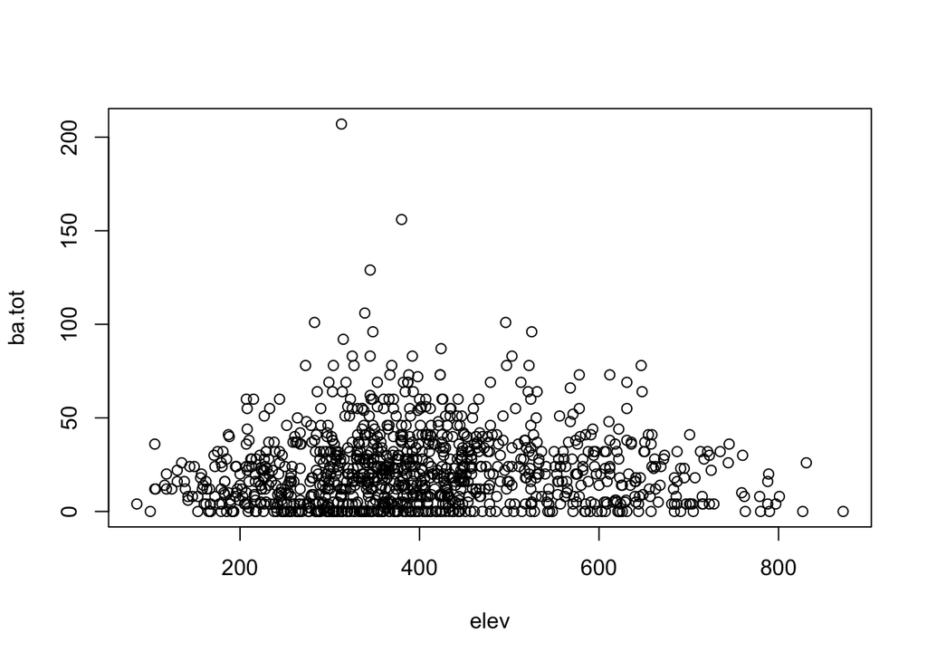

```r
plot(ba.tot ~ elev, data = data_all)
```

```r
sample(data_all$CEWA, 100)
```

```
##   [1] 0 0 0 0 0 0 0 0 0 0 0 0 0 0 0 0 0 0 0 5 0 0 0 0 0 0 0 0 0 0 0 0 0 0 0 0 0
##  [38] 4 0 0 0 0 0 0 0 0 0 0 0 0 0 0 0 0 0 0 0 0 0 0 0 0 0 0 0 0 0 0 0 0 0 0 0 0
##  [75] 0 0 0 0 1 0 0 0 0 0 0 0 0 0 0 0 0 0 0 0 0 0 0 0 0 0
```

```r
my_vec = rep(1:3, 5)
my_vec > 1
```

```
##  [1] FALSE  TRUE  TRUE FALSE  TRUE  TRUE FALSE  TRUE  TRUE FALSE  TRUE  TRUE
## [13] FALSE  TRUE  TRUE
```

```r
sample(data_all$CEWA, 100)
```

```
##   [1] 0 2 0 0 0 0 0 0 0 0 0 0 0 0 0 0 0 0 0 0 1 0 0 0 0 0 0 0 0 0 2 0 0 0 0 0 0
##  [38] 0 0 0 0 0 0 0 0 0 0 0 0 0 0 0 0 0 0 0 0 0 0 0 0 0 0 0 0 0 0 0 2 1 0 0 0 0
##  [75] 0 0 0 0 0 0 0 0 0 0 0 0 0 0 0 0 0 0 0 0 0 0 0 0 0 0
```

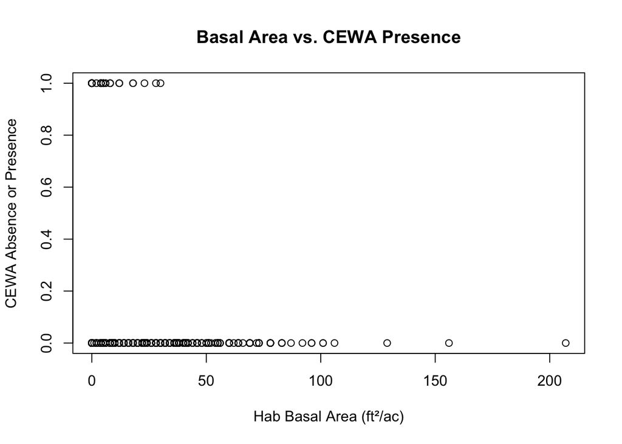

```r
cewa_present_absent <- as.numeric(dat_bird$CEWA > 0)

plot(x = dat_hab$ba.tot, y = cewa_present_absent, main = "Basal Area vs. CEWA Presence", xlab = "Hab Basal Area (ft²/ac)", ylab = "CEWA Absence or Presence")
```

# **Bird Species 1 and 2**

Q3/Q5 (1 pt.): Include a figure of your logistic function plot. Your figure must include the name of the bird species, appropriate title, axes, etc.

**Find Graph Below**

Q4/Q6 (3 pts.): Qualitatively describe the bird’s presence/absence patterns in terms of basal area (or your other chosen predictor).

```r
get_logistic_param_a = function(slope, midpoint)
{
  b = slope / 4
  return (-midpoint * (slope / 4))
}

# Function to calculate the logistic parameter b given the slope
get_logistic_param_b = function(slope)
{
  return (slope / 4)
}


# Calculate the value of the logistic function at x, given the parameters a and b.
logistic = function(x, a, b)
{
  val = exp(a + b * x)
  return(val / (1 + val))
}

# Calculate the value of the logistic function at x, given a slope and midpoint.
logistic_midpoint_slope = function(x, midpoint, slope)
{
  b = get_logistic_param_b(slope)
  a = get_logistic_param_a(slope, midpoint)
  return(logistic(x, a, b))
}

apply(dat_bird[, -c(1, 2, 3)], 2, sum)
```

```
##       AMCR       AMDI       AMGO       AMRO       BCCH       BEWR       BGWA
##     2.0000     3.0000   103.0000   306.0000    17.0000    43.0000    80.0000
##       BHCO       BHGR       BRCR       BTPI       BUSH       CBCH       CEWA
##     2.0000   404.0000   545.0000   156.0000    62.0000  1356.0000   116.0000
##       CORA       COYE       DEJU       DOWO       EUST       EVGR       GCKI
##    15.0000     3.0000   266.0000    13.0000     1.0000   380.0000   847.0000
##       GCSP       GRJA       HAFL       HAWO       HETH       HEWA       HOME
##    11.0000   181.0000   213.0000   243.0000    14.0000   682.0000     5.0000
##       HOWR       HUVI       MALL       MAMU       MGWA       MOQU       NOFL
##    43.0000   119.0000     2.0000     4.0000   167.0000     2.0000    31.0000
##       OCWA       OSFL       PISI       PIWO       PSFL       PUFI       PYOW
##   278.0000    27.0000    12.0000    23.0000  1419.0000   103.0000     7.0000
##       RBNU       RBSA       RCKI       RECR       RSTO       RTHA       RUGR
##    72.0000    19.0000     9.0000   452.0000   143.0000    13.0000     3.0000
##       RUHU       SCOW       SOSP       SOVI       SPOW       SSHA       STJA
##   384.0000     1.0000   419.0000     1.0000     2.0000     1.0000   458.0000
##       SWTH       TOSO       TOWA       TRSW       UNBI       UNFL       UNTH
##  2295.0000    15.0000    14.0000     5.0000    55.0000     1.0000     2.0000
##       UNWA       UNWO       VATH       VGSW       WAVI       WCSP       WEBL
##    21.0000    13.0000   376.0000    23.0000   202.0000   113.0000    15.0000
##       WETA       WIFL       WIWA       WIWR       WODU       WREN       WWPE
##    79.0000    47.0000  1747.0000  1523.0000     2.0000    70.0000    15.0000
##       YRWA    b.total     b.rich     b.sidi
##    27.0000 16943.0000 10114.0000   144.4053
```

```r
sample(data_all$SCOW, 100)
```

```
##   [1] 0 0 0 0 0 0 0 0 0 0 0 0 0 0 0 0 0 0 0 0 0 0 0 0 0 0 0 0 0 0 0 0 0 0 0 0 0
##  [38] 0 0 0 0 0 0 0 0 0 0 0 0 0 0 0 0 0 0 0 0 0 0 0 0 0 0 0 0 0 0 0 0 0 0 0 0 0
##  [75] 0 0 0 0 0 0 0 0 0 0 0 0 0 0 0 0 0 0 0 0 0 0 0 0 0 0
```

```r
my_vec = rep(1:3, 5)
my_vec > 1
```

```
##  [1] FALSE  TRUE  TRUE FALSE  TRUE  TRUE FALSE  TRUE  TRUE FALSE  TRUE  TRUE
## [13] FALSE  TRUE  TRUE
```

```r
sample(data_all$SWTH, 100)
```

```
##   [1] 2 2 1 1 3 2 2 3 2 4 3 2 1 1 0 4 3 2 4 3 3 2 0 0 4 2 2 2 2 1 1 5 1 1 0 5 3
##  [38] 1 4 1 1 2 2 3 1 2 2 6 0 3 2 4 3 2 1 3 2 2 0 2 3 2 1 3 5 3 5 4 3 1 2 2 1 1
##  [75] 4 4 1 1 2 1 1 0 1 1 2 1 3 1 4 2 2 3 1 1 1 2 3 1 0 3
```

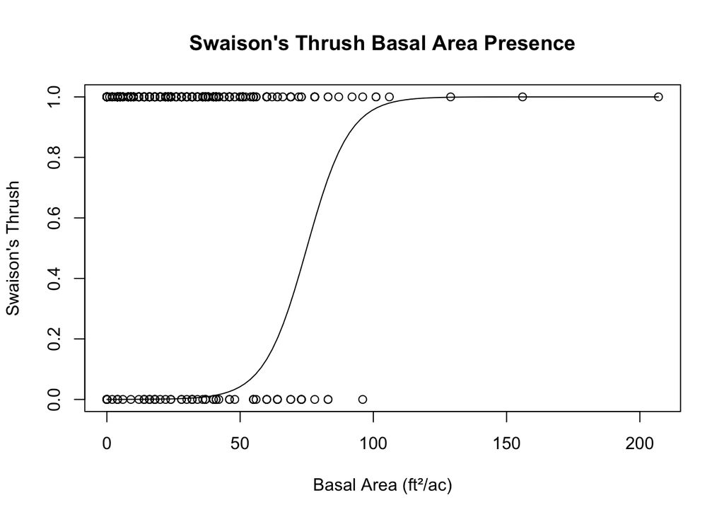

```r
SWTH_present_absent <- as.numeric(dat_bird$SWTH > 0)
plot(x = dat_hab$ba.tot, y = SWTH_present_absent, main = "Swaison's Thrush Basal Area Presence", xlab = "Basal Area (ft²/ac)", ylab = "Swaison's Thrush" )
curve(logistic_midpoint_slope(x, midpoint = 75, slope = 0.5), add = TRUE)
```

```r
sample(data_all$WIWR, 100)
```

```
##   [1] 2 2 2 1 2 4 3 0 1 0 2 2 1 3 0 4 1 0 0 2 1 0 3 2 1 1 2 2 1 4 1 2 2 3 2 0 2
##  [38] 1 0 1 1 2 1 0 2 0 1 3 0 2 0 1 2 2 0 1 1 1 2 0 1 1 1 1 0 1 1 0 2 1 0 1 0 0
##  [75] 0 3 2 1 3 3 3 0 1 2 1 4 4 1 2 0 0 1 2 1 1 3 2 3 3 1
```

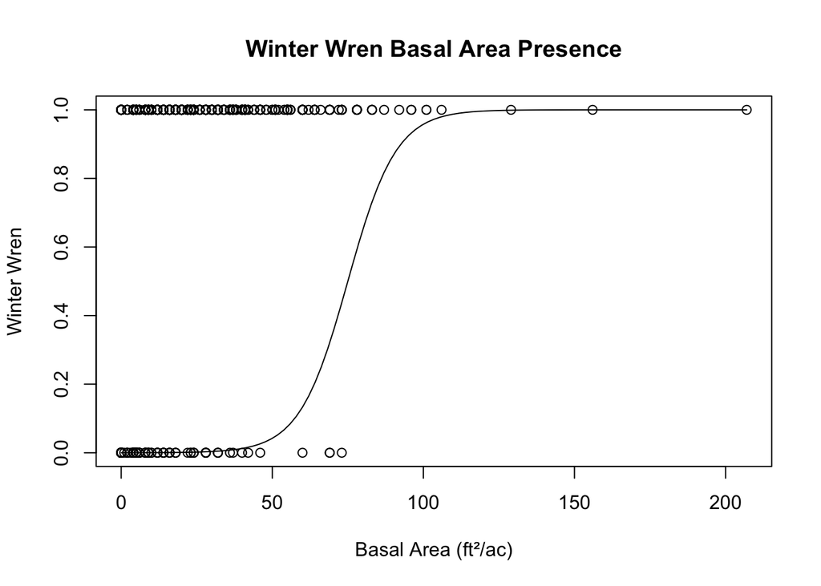

```r
WIWR_present_absent <- as.numeric(dat_bird$WIWR > 0)
plot(x = dat_hab$ba.tot, y = WIWR_present_absent, main = "Winter Wren Basal Area Presence", xlab = "Basal Area (ft²/ac)", ylab = "Winter Wren")
curve(logistic_midpoint_slope(x, midpoint = 75, slope = 0.5), add = TRUE)
```

```r
#Elev
sample(data_all$SWTH, 100)
```

```
##   [1] 3 3 3 2 3 1 3 2 2 1 0 6 3 1 2 0 2 3 2 3 1 3 1 1 2 2 3 2 3 1 0 1 1 2 2 2 1
##  [38] 3 1 1 3 3 2 2 3 4 2 5 3 2 2 1 2 1 3 1 1 3 1 2 4 2 3 2 4 2 3 4 2 3 2 2 3 3
##  [75] 3 2 0 1 1 1 4 1 2 3 4 5 2 1 1 4 2 2 1 2 2 1 1 1 5 2
```

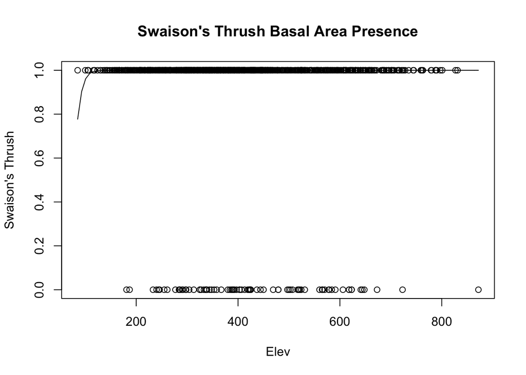

```r
SWTH_present_absent <- as.numeric(dat_bird$SWTH > 0)
plot(x = dat_hab$elev, y = SWTH_present_absent, main = "Swaison's Thrush Basal Area Presence", xlab = "Elev", ylab = "Swaison's Thrush" )
curve(logistic_midpoint_slope(x, midpoint = 75, slope = 0.5), add = TRUE)
```

```r
sample(data_all$WIWR, 100)
```

```
##   [1] 3 3 0 2 0 1 1 0 3 0 2 0 2 1 2 1 3 1 0 0 2 2 0 1 2 0 3 2 1 0 0 2 1 2 2 2 0
##  [38] 1 1 3 1 1 1 0 3 0 3 0 2 1 1 1 3 2 2 2 1 4 2 2 0 2 2 1 1 1 0 0 1 1 4 1 3 1
##  [75] 1 0 1 2 0 1 1 1 0 3 1 3 1 1 2 2 1 1 1 2 3 2 3 1 1 2
```

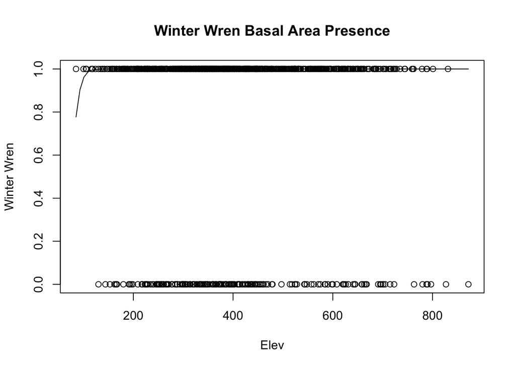

```r
WIWR_present_absent <- as.numeric(dat_bird$WIWR > 0)
plot(x = dat_hab$elev, y = WIWR_present_absent, main = "Winter Wren Basal Area Presence", xlab = "Elev", ylab = "Winter Wren")
curve(logistic_midpoint_slope(x, midpoint = 75, slope = 0.5), add = TRUE)
```

# **Gray Jays**

Q7 (1 pt.): How many total number of Gray Jays were observed in all of the sampling sites.

181 Gray Jays were observed in all of the sampling sites.

Q8 (2 pts.): Show the R code you used to perform the calculation.

sum(data_all$GRJA)

Q9 (1 pt.): Calculate the total number of sampling sites in which Gray Jays were observed.

Gray Jays were observed in 110 sampling sites

Q10 (2 pts.): Include the R code you used to perform the presence/absence calculation.

sum(GRJA_present_absent)

```r
sample(data_all$GRJA, 100)
```

```
##   [1] 1 0 0 0 0 0 0 0 2 0 0 0 0 0 0 1 0 0 0 0 0 1 0 0 0 0 0 0 0 2 0 0 0 0 0 0 0
##  [38] 0 0 0 0 0 0 0 0 0 0 1 0 0 1 0 0 0 0 0 0 0 0 0 0 0 0 0 0 0 2 0 0 2 2 0 0 0
##  [75] 0 0 0 0 0 0 3 0 0 0 0 0 0 0 0 0 0 0 0 0 0 0 0 2 0 0
```

```r
GRJA_present_absent = as.numeric(dat_bird$GRJA >0)

sum(GRJA_present_absent)
```

```
## [1] 110
```

```r
sum(data_all$GRJA)
```

```
## [1] 181
```